# STRprofiler Shiny Application Usage

Michael W. Lloyd, The Jackson Laboratory

Jared Andrews, St. Jude Children’s Research Hospital

**This site and tool are intended for research purposes only.**

# Database Queries

The report will differ depending on if an individual sample or batch of samples is provided.

## Default Database

Current data underlying the default database were provided by [The Jackson Laboratory PDX program](https://tumor.informatics.jax.org/mtbwi/pdxSearch.do), and the [NCI Patient-Derived Models Repository (PDMR)](https://pdmr.cancer.gov/).

If this app is hosted with a custom database, please contact the host for information on the database source.

## CLASTR / Cellosaurus API Query

Query of the [Cellosaurus](https://www.cellosaurus.org/description.html) (Bairoch, 2018) cell line database is also available for single and batch samples via the [CLASTR](https://www.cellosaurus.org/str-search/) (Robin, Capes-Davis, and Bairoch, 2019) [REST API](https://www.cellosaurus.org/str-search/help.html#5).

## Single Query Report

For individual samples, a report is generated with the following fields when ‘STRprofiler Database’ is selected as the search type.

| Output Field | Description |
| --- | --- |
| Mixed Sample | Flag to indicate sample mixing. Sample mixing is determined by the “‘Mixed’ Sample Threshold” option. If more markers are tri+ allelic than the threshold, samples are flagged as potentially mixed. |
| Shared Markers | Number of markers shared between the query and database sample. |
| Shared Alleles | Number of alleles shared between the query and database sample. |
| Tanabe Score | Tanabe similarity score between the query and database sample (if Tanabe selected). |
| Master Query Score | Master ‘Query’ similarity score between the query and database sample (if Master Query selected). |
| Master Ref Score | Master ‘Reference’ similarity score between the query and database sample (if Master Ref selected). |
| Markers 1 … n | Marker alleles with mismatches highlighted. |

The report is filtered to include only those samples with greater than or equal to the `Similarity Score Filter Threshold` defined by the user, and report only the similarity score selected.

When `Cellosaurus Database (CLASTR)` is selected as the search type, a report is generated with the following fields:

| Output Field | Description |
| --- | --- |
| Accession | Cellosaurus cell line accession ID. Links are provided to each accession information page. |
| Name | Cell line name. |
| Score | Similarity score between the query and cell line sample. Reported score reflectes the selected Similarity Score Filter. |
| Markers 1 … n | Marker alleles with mismatches highlighted. |

The report is filtered to include only those samples with greater than or equal to the `Similarity Score Filter Threshold` defined by the user.

## Batch Query Report

For batched samples, a summary report is generated.

[output not shown]

The report is filtered to include only those samples with greater than or equal to the `Similarity Score Filter Thresholds` defined by the user.

When `Cellosaurus Database (CLASTR)` is selected as the search type, a report is generated in XLSX format, and can be downloaded via the `Download XLSX` button. These results will not be displayed in the app window directly, they must be downloaded.

## Database File Management

Users can upload custom database files. The files must be in CSV format. A ‘Sample’ header must be present, but custom marker names may be used. Note that to score `Amelogenin` using the option provided, there must be a `Amelogenin` header in the uploaded file.

Alleles are expected to be repeat counts, e.g. `12` or `9.3`. The only non-numeric alleles recognized are the Amelogenin sex markers `X` and `Y`. Any other non-numeric call - off-ladder (`OL`), ambiguous (`?`), `NR`, `ND` and the like - is discarded and never counted as an allele, whether it comes from an uploaded database or is typed into a marker box.

Optional `Center` and `Passage` columns are recognized as sample metadata rather than markers. They are displayed alongside results, but are excluded from similarity scoring and mixing checks. They may also be present in batch query files.

# Reported Similarity Scores

1. [Tanabe, AKA the Sørenson-Dice coefficient](https://www.doi.org/10.11418/jtca1981.18.4_329):

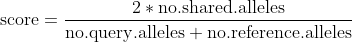

# Query Options

## Sample Query Options

- Amelogenin scoring is excluded by default but can be included by selecting the option.
- ‘Mixed’ Sample Threshold: is the number of markers with > 2 alleles allowed before a sample is flagged for potential mixing. [default: 3]
- Similarity Score Filter: is the similiarity score used for result filtering. [default: Tanabe]
- Similarity Score Filter Threshold: is the threshold to filter results. Only those samples with >= the threshold will appear in results. [default: 80]

## Batch Query Specific

`STRprofiler Database` and `Within File` options:

- Amelogenin scoring is excluded by default but can be included by selecting the option.
- Tanabe Filter Threshold: is the Tanabe score threshold over which a sample is considered a match in batch and file queries. [default: 80]
- Masters (vs. query) Filter Threshold: is the Masters (vs. query) score threshold over which a sample is considered a match in batch and file queries. [default: 80]
- Masters (vs. reference) Filter Threshold: is the Masters (vs. reference) score threshold over which a sample is considered a match in batch and file queries. [default: 80]

`Cellosaurus Database (CLASTR)` options:

- Similarity Score Filter: is the similiarity score used for result filtering. [default: Tanabe]
- Similarity Score Filter Threshold: is the threshold to filter results. Only those samples with >= the threshold will appear in results. [default: 80]

# Python Package & CLI

**STRprofiler** also has a command line interface through a python package available from [PyPI](https://pypi.org/project/strprofiler/). The full docs are available on [ReadTheDocs](https://strprofiler.readthedocs.io/en/latest/).

# References

`STRprofiler` is provided under the MIT license. If you use this app in your research, please cite:  
Jared M Andrews, Michael W Lloyd, Steven B Neuhauser, Margaret Bundy, Emily L Jocoy, Susan D Airhart, Carol J Bult, Yvonne A Evrard, Jeffrey H Chuang, Suzanne Baker, STRprofiler: efficient comparisons of short tandem repeat profiles for biomedical model authentication, Bioinformatics, 2024;, btae713,https://doi.org/10.1093/bioinformatics/btae713

If you use the `strprofiler clastr` command or Cellosaurus database in the app, please cite:

Bairoch A. (2018) The Cellosaurus, a cell line knowledge resource. Journal of Biomolecular Techniques. 29:25-38. DOI: 10.7171/jbt.18-2902-002; PMID: 29805321

Robin, T., Capes-Davis, A. & Bairoch, A. (2019) CLASTR: the Cellosaurus STR Similarity Search Tool - A Precious Help for Cell Line Authentication. International Journal of Cancer. PubMed: 31444973 DOI: 10.1002/IJC.32639